# Project: Investigate a Dataset - [TMDb movie data]

- Introduction
- Data Wrangling
- Exploratory Data Analysis
- Conclusions

## Introduction

### Dataset Description

> This data set contains information about 10,000 movies collected from The Movie Database (TMDb), including user ratings and revenue.This dataset contains information such as the budget, genres, casting. This investigation will analyse the information using relevant packages taught to make a decision on where focus should be for the copany's resources The original of this data has already been cleaned from Kaggle

### Question(s) for Analysis

> For the purpose of this investigation I will be analysing the data using skills taught such as:
> - Data importation
> - Data wrangling
> - Data cleaning
> - Data analysis
> - Data reporting

First I set up import statements for all of the packages that I plan to use.

```python
def my_project():
    print("Hello this is the start of my project")
```

```python
my_project()
```

```
Hello this is the start of my project
```

```python
import pandas as pd
import numpy as np
import matplotlib.pyplot as plt
import seaborn as sns

%matplotlib inline
```

```python
# Upgrade pandas to use dataframe.explode() function.
!pip install --upgrade pandas==0.25.0
```

## Data Wrangling

In this section of the report, I will load in the data, check for cleanliness, and then trim and clean the dataset for analysis.

> This will involve removing duplicates, null cells, redundant cells, drop columns, remove spaces and rename the columns while finding out general information about my dataset.

```python
#Here I load my data and print out a few lines, while operations to inspect data
#   types and look for instances of missing or possibly errant data.
df = pd.read_csv("tmdb-movies.csv")
df.head()
```

|  | id | imdb_id | popularity | budget | revenue | original_title | cast | homepage | director | tagline | ... | overview | runtime | genres | production_companies | release_date | vote_count | vote_average | release_year | budget_adj | revenue_adj |
| --- | --- | --- | --- | --- | --- | --- | --- | --- | --- | --- | --- | --- | --- | --- | --- | --- | --- | --- | --- | --- | --- |
| 0 | 135397 | tt0369610 | 32.985763 | 150000000 | 1513528810 | Jurassic World | Chris Pratt\|Bryce Dallas Howard\|Irrfan Khan\|Vi... | http://www.jurassicworld.com/ | Colin Trevorrow | The park is open. | ... | Twenty-two years after the events of Jurassic ... | 124 | Action\|Adventure\|Science Fiction\|Thriller | Universal Studios\|Amblin Entertainment\|Legenda... | 6/9/15 | 5562 | 6.5 | 2015 | 1.379999e+08 | 1.392446e+09 |
| 1 | 76341 | tt1392190 | 28.419936 | 150000000 | 378436354 | Mad Max: Fury Road | Tom Hardy\|Charlize Theron\|Hugh Keays-Byrne\|Nic... | http://www.madmaxmovie.com/ | George Miller | What a Lovely Day. | ... | An apocalyptic story set in the furthest reach... | 120 | Action\|Adventure\|Science Fiction\|Thriller | Village Roadshow Pictures\|Kennedy Miller Produ... | 5/13/15 | 6185 | 7.1 | 2015 | 1.379999e+08 | 3.481613e+08 |
| 2 | 262500 | tt2908446 | 13.112507 | 110000000 | 295238201 | Insurgent | Shailene Woodley\|Theo James\|Kate Winslet\|Ansel... | http://www.thedivergentseries.movie/#insurgent | Robert Schwentke | One Choice Can Destroy You | ... | Beatrice Prior must confront her inner demons ... | 119 | Adventure\|Science Fiction\|Thriller | Summit Entertainment\|Mandeville Films\|Red Wago... | 3/18/15 | 2480 | 6.3 | 2015 | 1.012000e+08 | 2.716190e+08 |
| 3 | 140607 | tt2488496 | 11.173104 | 200000000 | 2068178225 | Star Wars: The Force Awakens | Harrison Ford\|Mark Hamill\|Carrie Fisher\|Adam D... | http://www.starwars.com/films/star-wars-episod... | J.J. Abrams | Every generation has a story. | ... | Thirty years after defeating the Galactic Empi... | 136 | Action\|Adventure\|Science Fiction\|Fantasy | Lucasfilm\|Truenorth Productions\|Bad Robot | 12/15/15 | 5292 | 7.5 | 2015 | 1.839999e+08 | 1.902723e+09 |
| 4 | 168259 | tt2820852 | 9.335014 | 190000000 | 1506249360 | Furious 7 | Vin Diesel\|Paul Walker\|Jason Statham\|Michelle ... | http://www.furious7.com/ | James Wan | Vengeance Hits Home | ... | Deckard Shaw seeks revenge against Dominic Tor... | 137 | Action\|Crime\|Thriller | Universal Pictures\|Original Film\|Media Rights ... | 4/1/15 | 2947 | 7.3 | 2015 | 1.747999e+08 | 1.385749e+09 |

5 rows × 21 columns

```python
df.info()
```

```
<class 'pandas.core.frame.DataFrame'>
RangeIndex: 10866 entries, 0 to 10865
Data columns (total 21 columns):
id                      10866 non-null int64
imdb_id                 10856 non-null object
popularity              10866 non-null float64
budget                  10866 non-null int64
revenue                 10866 non-null int64
original_title          10866 non-null object
cast                    10790 non-null object
homepage                2936 non-null object
director                10822 non-null object
tagline                 8042 non-null object
keywords                9373 non-null object
overview                10862 non-null object
runtime                 10866 non-null int64
genres                  10843 non-null object
production_companies    9836 non-null object
release_date            10866 non-null object
vote_count              10866 non-null int64
vote_average            10866 non-null float64
release_year            10866 non-null int64
budget_adj              10866 non-null float64
revenue_adj             10866 non-null float64
dtypes: float64(4), int64(6), object(11)
memory usage: 1.7+ MB
```

```python
df.dtypes
```

```
id                        int64
imdb_id                  object
popularity              float64
budget                    int64
revenue                   int64
original_title           object
cast                     object
homepage                 object
director                 object
tagline                  object
keywords                 object
overview                 object
runtime                   int64
genres                   object
production_companies     object
release_date             object
vote_count                int64
vote_average            float64
release_year              int64
budget_adj              float64
revenue_adj             float64
dtype: object
```

```python
df.duplicated().sum()
```

```
1
```

```python
df.shape
```

```
(10866, 21)
```

There are 10866 rows and 21 columns in the uncleaned dataset with wrongly allocated data set types, it also has 1 duplicated item and missing cells

### Data Cleaning

> **Tip**: Make sure that you keep your reader informed on the steps that you are taking in your investigation. Follow every code cell, or every set of related code cells, with a markdown cell to describe to the reader what was found in the preceding cell(s). Try to make it so that the reader can then understand what they will be seeing in the following cell(s).

I start by first dropping the duplicated cells

```python
df.drop_duplicates(inplace=True)
```

I then check if there are any duplicates left

```python
df.duplicated().any()
```

```
False
```

I then remove all null values in the dataset

```python
df.isnull().sum()
```

```
id                         0
imdb_id                   10
popularity                 0
budget                     0
revenue                    0
original_title             0
cast                      76
homepage                7929
director                  44
tagline                 2824
keywords                1493
overview                   4
runtime                    0
genres                    23
production_companies    1030
release_date               0
vote_count                 0
vote_average               0
release_year               0
budget_adj                 0
revenue_adj                0
dtype: int64
```

```python
df.dropna(inplace=True)
```

I then check if there are stil any left

```python
df.isnull().any()
```

```
id                      False
imdb_id                 False
popularity              False
budget                  False
revenue                 False
original_title          False
cast                    False
homepage                False
director                False
tagline                 False
keywords                False
overview                False
runtime                 False
genres                  False
production_companies    False
release_date            False
vote_count              False
vote_average            False
release_year            False
budget_adj              False
revenue_adj             False
dtype: bool
```

I then remove all redundant cells

```python
df.head()
```

|  | id | imdb_id | popularity | budget | revenue | original_title | cast | homepage | director | tagline | ... | overview | runtime | genres | production_companies | release_date | vote_count | vote_average | release_year | budget_adj | revenue_adj |
| --- | --- | --- | --- | --- | --- | --- | --- | --- | --- | --- | --- | --- | --- | --- | --- | --- | --- | --- | --- | --- | --- |
| 0 | 135397 | tt0369610 | 32.985763 | 150000000 | 1513528810 | Jurassic World | Chris Pratt\|Bryce Dallas Howard\|Irrfan Khan\|Vi... | http://www.jurassicworld.com/ | Colin Trevorrow | The park is open. | ... | Twenty-two years after the events of Jurassic ... | 124 | Action\|Adventure\|Science Fiction\|Thriller | Universal Studios\|Amblin Entertainment\|Legenda... | 6/9/15 | 5562 | 6.5 | 2015 | 1.379999e+08 | 1.392446e+09 |
| 1 | 76341 | tt1392190 | 28.419936 | 150000000 | 378436354 | Mad Max: Fury Road | Tom Hardy\|Charlize Theron\|Hugh Keays-Byrne\|Nic... | http://www.madmaxmovie.com/ | George Miller | What a Lovely Day. | ... | An apocalyptic story set in the furthest reach... | 120 | Action\|Adventure\|Science Fiction\|Thriller | Village Roadshow Pictures\|Kennedy Miller Produ... | 5/13/15 | 6185 | 7.1 | 2015 | 1.379999e+08 | 3.481613e+08 |
| 2 | 262500 | tt2908446 | 13.112507 | 110000000 | 295238201 | Insurgent | Shailene Woodley\|Theo James\|Kate Winslet\|Ansel... | http://www.thedivergentseries.movie/#insurgent | Robert Schwentke | One Choice Can Destroy You | ... | Beatrice Prior must confront her inner demons ... | 119 | Adventure\|Science Fiction\|Thriller | Summit Entertainment\|Mandeville Films\|Red Wago... | 3/18/15 | 2480 | 6.3 | 2015 | 1.012000e+08 | 2.716190e+08 |
| 3 | 140607 | tt2488496 | 11.173104 | 200000000 | 2068178225 | Star Wars: The Force Awakens | Harrison Ford\|Mark Hamill\|Carrie Fisher\|Adam D... | http://www.starwars.com/films/star-wars-episod... | J.J. Abrams | Every generation has a story. | ... | Thirty years after defeating the Galactic Empi... | 136 | Action\|Adventure\|Science Fiction\|Fantasy | Lucasfilm\|Truenorth Productions\|Bad Robot | 12/15/15 | 5292 | 7.5 | 2015 | 1.839999e+08 | 1.902723e+09 |
| 4 | 168259 | tt2820852 | 9.335014 | 190000000 | 1506249360 | Furious 7 | Vin Diesel\|Paul Walker\|Jason Statham\|Michelle ... | http://www.furious7.com/ | James Wan | Vengeance Hits Home | ... | Deckard Shaw seeks revenge against Dominic Tor... | 137 | Action\|Crime\|Thriller | Universal Pictures\|Original Film\|Media Rights ... | 4/1/15 | 2947 | 7.3 | 2015 | 1.747999e+08 | 1.385749e+09 |

5 rows × 21 columns

in the data set, I find that columns such as “imdb_id”, “homepage”, “tagline”, “keywords”, “overview”, “vote_average” are not useful for the purpose of this analysis, as such can be removed from the dataframe

```python
dele_col=['imdb_id', 'homepage','tagline', 'keywords', 'overview','vote_average']
df_mov = df.drop(columns= dele_col)
```

```python
list(df_mov.columns)
```

```
['id',
 'popularity',
 'budget',
 'revenue',
 'original_title',
 'cast',
 'director',
 'runtime',
 'genres',
 'production_companies',
 'release_date',
 'vote_count',
 'release_year',
 'budget_adj',
 'revenue_adj']
```

```python
df_mov.to_csv("tmdb-movies_clean.csv")
```

```python
# After discussing the structure of the data and any problems that need to be
#   cleaned, perform those cleaning steps in the second part of this section.
df_01= pd.read_csv("tmdb-movies_clean.csv")
df_01.info()
```

```
<class 'pandas.core.frame.DataFrame'>
RangeIndex: 1992 entries, 0 to 1991
Data columns (total 16 columns):
Unnamed: 0              1992 non-null int64
id                      1992 non-null int64
popularity              1992 non-null float64
budget                  1992 non-null int64
revenue                 1992 non-null int64
original_title          1992 non-null object
cast                    1992 non-null object
director                1992 non-null object
runtime                 1992 non-null int64
genres                  1992 non-null object
production_companies    1992 non-null object
release_date            1992 non-null object
vote_count              1992 non-null int64
release_year            1992 non-null int64
budget_adj              1992 non-null float64
revenue_adj             1992 non-null float64
dtypes: float64(3), int64(7), object(6)
memory usage: 249.1+ KB
```

```python
df_01.head(1)
```

|  | Unnamed: 0 | id | popularity | budget | revenue | original_title | cast | director | runtime | genres | production_companies | release_date | vote_count | release_year | budget_adj | revenue_adj |
| --- | --- | --- | --- | --- | --- | --- | --- | --- | --- | --- | --- | --- | --- | --- | --- | --- |
| 0 | 0 | 135397 | 32.985763 | 150000000 | 1513528810 | Jurassic World | Chris Pratt\|Bryce Dallas Howard\|Irrfan Khan\|Vi... | Colin Trevorrow | 124 | Action\|Adventure\|Science Fiction\|Thriller | Universal Studios\|Amblin Entertainment\|Legenda... | 6/9/15 | 5562 | 2015 | 1.379999e+08 | 1.392446e+09 |

```python
df_01.reset_index(drop=True, inplace=True)
```

```python
list(df_01.columns)
```

```
['Unnamed: 0',
 'id',
 'popularity',
 'budget',
 'revenue',
 'original_title',
 'cast',
 'director',
 'runtime',
 'genres',
 'production_companies',
 'release_date',
 'vote_count',
 'release_year',
 'budget_adj',
 'revenue_adj']
```

Remove redundant index column

```python
drop_ind = df_01.columns[:1]
df_02= df_01.drop(columns= 'Unnamed: 0')
list(df_02.columns)
```

```
['id',
 'popularity',
 'budget',
 'revenue',
 'original_title',
 'cast',
 'director',
 'runtime',
 'genres',
 'production_companies',
 'release_date',
 'vote_count',
 'release_year',
 'budget_adj',
 'revenue_adj']
```

```python
df_02.head(1)
```

|  | id | popularity | budget | revenue | original_title | cast | director | runtime | genres | production_companies | release_date | vote_count | release_year | budget_adj | revenue_adj |
| --- | --- | --- | --- | --- | --- | --- | --- | --- | --- | --- | --- | --- | --- | --- | --- |
| 0 | 135397 | 32.985763 | 150000000 | 1513528810 | Jurassic World | Chris Pratt\|Bryce Dallas Howard\|Irrfan Khan\|Vi... | Colin Trevorrow | 124 | Action\|Adventure\|Science Fiction\|Thriller | Universal Studios\|Amblin Entertainment\|Legenda... | 6/9/15 | 5562 | 2015 | 1.379999e+08 | 1.392446e+09 |

```python
df_02.info()
```

```
<class 'pandas.core.frame.DataFrame'>
RangeIndex: 1992 entries, 0 to 1991
Data columns (total 15 columns):
id                      1992 non-null int64
popularity              1992 non-null float64
budget                  1992 non-null int64
revenue                 1992 non-null int64
original_title          1992 non-null object
cast                    1992 non-null object
director                1992 non-null object
runtime                 1992 non-null int64
genres                  1992 non-null object
production_companies    1992 non-null object
release_date            1992 non-null object
vote_count              1992 non-null int64
release_year            1992 non-null int64
budget_adj              1992 non-null float64
revenue_adj             1992 non-null float64
dtypes: float64(3), int64(6), object(6)
memory usage: 233.6+ KB
```

From the remaining dataset we have 1992 rows and 15 columns

```python
#Before answering the questions, lets figure out the profits and the profits adjusted for inflation of each movie
df_02['profit'] = df_02['revenue']-df_02['budget']
df_02['profit_adj'] = df_02['revenue_adj']-df_02['budget_adj']
df_02['profit'] = df_02['profit'].apply(np.int64)
df_02['profit_adj'] = df_02['profit_adj'].apply(np.int64)
df_02['budget'] = df_02['budget'].apply(np.int64)
df_02['revenue'] = df_02['revenue'].apply(np.int64)
df_02['budget_adj'] = df_02['budget_adj'].apply(np.int64)
df_02['revenue_adj'] = df_02['revenue_adj'].apply(np.int64)
```

```python
df_02.head(1)
```

|  | id | popularity | budget | revenue | original_title | cast | director | runtime | genres | production_companies | release_date | vote_count | release_year | budget_adj | revenue_adj | profit | profit_adj |
| --- | --- | --- | --- | --- | --- | --- | --- | --- | --- | --- | --- | --- | --- | --- | --- | --- | --- |
| 0 | 135397 | 32.985763 | 150000000 | 1513528810 | Jurassic World | Chris Pratt\|Bryce Dallas Howard\|Irrfan Khan\|Vi... | Colin Trevorrow | 124 | Action\|Adventure\|Science Fiction\|Thriller | Universal Studios\|Amblin Entertainment\|Legenda... | 6/9/15 | 5562 | 2015 | 137999939 | 1392445892 | 1363528810 | 1254445953 |

```python
df_02.dtypes
```

```
id                        int64
popularity              float64
budget                    int64
revenue                   int64
original_title           object
cast                     object
director                 object
runtime                   int64
genres                   object
production_companies     object
release_date             object
vote_count                int64
release_year              int64
budget_adj                int64
revenue_adj               int64
profit                    int64
profit_adj                int64
dtype: object
```

```python
df_02['release_date'] = pd.to_datetime(df_02['release_date'], format= '%m%d%Y')
df_02['release_year'] = pd.to_datetime(df_02['release_year'], format= '%YYYY')
df_02.dtypes
```

```
id                               int64
popularity                     float64
budget                           int64
revenue                          int64
original_title                  object
cast                            object
director                        object
runtime                          int64
genres                          object
production_companies            object
release_date            datetime64[ns]
vote_count                       int64
release_year            datetime64[ns]
budget_adj                       int64
revenue_adj                      int64
profit                           int64
profit_adj                       int64
dtype: object
```

## Exploratory Data Analysis

> **Tip**: Now that you've trimmed and cleaned your data, you're ready to move on to exploration. **Compute statistics** and **create visualizations** with the goal of addressing the research questions that you posed in the Introduction section. You should compute the relevant statistics throughout the analysis when an inference is made about the data. Note that at least two or more kinds of plots should be created as part of the exploration, and you must compare and show trends in the varied visualizations.

> **Tip**: - Investigate the stated question(s) from multiple angles. It is recommended that you be systematic with your approach. Look at one variable at a time, and then follow it up by looking at relationships between variables. You should explore at least three variables in relation to the primary question. This can be an exploratory relationship between three variables of interest, or looking at how two independent variables relate to a single dependent variable of interest. Lastly, you should perform both single-variable (1d) and multiple-variable (2d) explorations.

First we find the all time highest and lowest for the movie profits

```python
df_02.head()
```

|  | id | popularity | budget | revenue | original_title | cast | director | runtime | genres | production_companies | release_date | vote_count | release_year | budget_adj | revenue_adj | profit | profit_adj |
| --- | --- | --- | --- | --- | --- | --- | --- | --- | --- | --- | --- | --- | --- | --- | --- | --- | --- |
| 0 | 135397 | 32.985763 | 150000000 | 1513528810 | Jurassic World | Chris Pratt\|Bryce Dallas Howard\|Irrfan Khan\|Vi... | Colin Trevorrow | 124 | Action\|Adventure\|Science Fiction\|Thriller | Universal Studios\|Amblin Entertainment\|Legenda... | 2015-06-09 | 5562 | 2015-01-01 | 137999939 | 1392445892 | 1363528810 | 1254445953 |
| 1 | 76341 | 28.419936 | 150000000 | 378436354 | Mad Max: Fury Road | Tom Hardy\|Charlize Theron\|Hugh Keays-Byrne\|Nic... | George Miller | 120 | Action\|Adventure\|Science Fiction\|Thriller | Village Roadshow Pictures\|Kennedy Miller Produ... | 2015-05-13 | 6185 | 2015-01-01 | 137999939 | 348161292 | 228436354 | 210161353 |
| 2 | 262500 | 13.112507 | 110000000 | 295238201 | Insurgent | Shailene Woodley\|Theo James\|Kate Winslet\|Ansel... | Robert Schwentke | 119 | Adventure\|Science Fiction\|Thriller | Summit Entertainment\|Mandeville Films\|Red Wago... | 2015-03-18 | 2480 | 2015-01-01 | 101199955 | 271619025 | 185238201 | 170419069 |
| 3 | 140607 | 11.173104 | 200000000 | 2068178225 | Star Wars: The Force Awakens | Harrison Ford\|Mark Hamill\|Carrie Fisher\|Adam D... | J.J. Abrams | 136 | Action\|Adventure\|Science Fiction\|Fantasy | Lucasfilm\|Truenorth Productions\|Bad Robot | 2015-12-15 | 5292 | 2015-01-01 | 183999919 | 1902723129 | 1868178225 | 1718723210 |
| 4 | 168259 | 9.335014 | 190000000 | 1506249360 | Furious 7 | Vin Diesel\|Paul Walker\|Jason Statham\|Michelle ... | James Wan | 137 | Action\|Crime\|Thriller | Universal Pictures\|Original Film\|Media Rights ... | 2015-04-01 | 2947 | 2015-01-01 | 174799923 | 1385748801 | 1316249360 | 1210948878 |

```python
sor_prof_high =df_02.sort_values(['profit','budget'], ascending=False).head(10)
sor_prof_high
```

|  | id | popularity | budget | revenue | original_title | cast | director | runtime | genres | production_companies | release_date | vote_count | release_year | budget_adj | revenue_adj | profit | profit_adj |
| --- | --- | --- | --- | --- | --- | --- | --- | --- | --- | --- | --- | --- | --- | --- | --- | --- | --- |
| 321 | 19995 | 9.432768 | 237000000 | 2781505847 | Avatar | Sam Worthington\|Zoe Saldana\|Sigourney Weaver\|S... | James Cameron | 162 | Action\|Adventure\|Fantasy\|Science Fiction | Ingenious Film Partners\|Twentieth Century Fox ... | 2009-12-10 | 8458 | 2009-01-01 | 240886902 | 2827123750 | 2544505847 | 2586236847 |
| 3 | 140607 | 11.173104 | 200000000 | 2068178225 | Star Wars: The Force Awakens | Harrison Ford\|Mark Hamill\|Carrie Fisher\|Adam D... | J.J. Abrams | 136 | Action\|Adventure\|Science Fiction\|Fantasy | Lucasfilm\|Truenorth Productions\|Bad Robot | 2015-12-15 | 5292 | 2015-01-01 | 183999919 | 1902723129 | 1868178225 | 1718723210 |
| 1347 | 597 | 4.355219 | 200000000 | 1845034188 | Titanic | Kate Winslet\|Leonardo DiCaprio\|Frances Fisher\|... | James Cameron | 194 | Drama\|Romance\|Thriller | Paramount Pictures\|Twentieth Century Fox Film ... | 1997-11-18 | 4654 | 1997-01-01 | 271692064 | 2506405735 | 1645034188 | 2234713671 |
| 0 | 135397 | 32.985763 | 150000000 | 1513528810 | Jurassic World | Chris Pratt\|Bryce Dallas Howard\|Irrfan Khan\|Vi... | Colin Trevorrow | 124 | Action\|Adventure\|Science Fiction\|Thriller | Universal Studios\|Amblin Entertainment\|Legenda... | 2015-06-09 | 5562 | 2015-01-01 | 137999939 | 1392445892 | 1363528810 | 1254445953 |
| 4 | 168259 | 9.335014 | 190000000 | 1506249360 | Furious 7 | Vin Diesel\|Paul Walker\|Jason Statham\|Michelle ... | James Wan | 137 | Action\|Crime\|Thriller | Universal Pictures\|Original Film\|Media Rights ... | 2015-04-01 | 2947 | 2015-01-01 | 174799923 | 1385748801 | 1316249360 | 1210948878 |
| 1162 | 24428 | 7.637767 | 220000000 | 1519557910 | The Avengers | Robert Downey Jr.\|Chris Evans\|Mark Ruffalo\|Chr... | Joss Whedon | 143 | Science Fiction\|Action\|Adventure | Marvel Studios | 2012-04-25 | 8903 | 2012-01-01 | 208943741 | 1443191435 | 1299557910 | 1234247693 |
| 905 | 12445 | 5.711315 | 125000000 | 1327817822 | Harry Potter and the Deathly Hallows: Part 2 | Daniel Radcliffe\|Rupert Grint\|Emma Watson\|Alan... | David Yates | 130 | Adventure\|Family\|Fantasy | Warner Bros.\|Heyday Films\|Moving Picture Compa... | 2011-07-07 | 3750 | 2011-01-01 | 121174755 | 1287183997 | 1202817822 | 1166009242 |
| 14 | 99861 | 5.944927 | 280000000 | 1405035767 | Avengers: Age of Ultron | Robert Downey Jr.\|Chris Hemsworth\|Mark Ruffalo... | Joss Whedon | 141 | Action\|Adventure\|Science Fiction | Marvel Studios\|Prime Focus\|Revolution Sun Studios | 2015-04-22 | 4304 | 2015-01-01 | 257599886 | 1292632336 | 1125035767 | 1035032450 |
| 1358 | 109445 | 6.112766 | 150000000 | 1274219009 | Frozen | Kristen Bell\|Idina Menzel\|Jonathan Groff\|Josh ... | Chris Buck\|Jennifer Lee | 102 | Animation\|Adventure\|Family | Walt Disney Pictures\|Walt Disney Animation Stu... | 2013-11-27 | 3369 | 2013-01-01 | 140405002 | 1192711491 | 1124219009 | 1052306488 |
| 8 | 211672 | 7.404165 | 74000000 | 1156730962 | Minions | Sandra Bullock\|Jon Hamm\|Michael Keaton\|Allison... | Kyle Balda\|Pierre Coffin | 91 | Family\|Animation\|Adventure\|Comedy | Universal Pictures\|Illumination Entertainment | 2015-06-17 | 2893 | 2015-01-01 | 68079970 | 1064192016 | 1082730962 | 996112046 |

```python
sor_prof_low =df_02.sort_values(['profit','budget'], ascending=False).tail(10)
sor_prof_low
```

|  | id | popularity | budget | revenue | original_title | cast | director | runtime | genres | production_companies | release_date | vote_count | release_year | budget_adj | revenue_adj | profit | profit_adj |
| --- | --- | --- | --- | --- | --- | --- | --- | --- | --- | --- | --- | --- | --- | --- | --- | --- | --- |
| 620 | 42888 | 0.640576 | 120000000 | 48668907 | How Do You Know | Reese Witherspoon\|Paul Rudd\|Owen Wilson\|Jack N... | James L. Brooks | 121 | Comedy\|Drama\|Romance | Columbia Pictures\|Gracie Films\|Road Rebel | 2010-12-17 | 136 | 2010-01-01 | 120000000 | 48668907 | -71331093 | -71331093 |
| 1529 | 10077 | 0.626900 | 80000000 | 5989640 | A Sound of Thunder | Heike Makatsch\|Armin Rohde\|David Oyelowo\|Wilfr... | Peter Hyams | 110 | Thriller\|Science Fiction\|Adventure\|Action | Epsilon Motion Pictures\|Franchise Pictures\|Bal... | 2005-05-15 | 58 | 2005-01-01 | 89325063 | 6687812 | -74010360 | -82637251 |
| 1338 | 19766 | 0.315387 | 80000000 | 0 | Inspector Gadget 2 | French Stewart\|Elaine Hendrix\|Tony Martin\|Cait... | Alex Zamm | 89 | Action\|Adventure\|Comedy\|Family | Walt Disney Pictures | 2003-03-11 | 55 | 2003-01-01 | 94828211 | 0 | -80000000 | -94828211 |
| 1385 | 146216 | 1.675461 | 84000000 | 0 | RED 2 | Bruce Willis\|Catherine Zeta-Jones\|Anthony Hopk... | Dean Parisot | 116 | Action\|Comedy\|Crime\|Thriller | DC Comics\|Di Bonaventura Pictures\|Summit Enter... | 2013-07-18 | 1109 | 2013-01-01 | 78626801 | 0 | -84000000 | -78626801 |
| 1583 | 11619 | 1.390297 | 149000000 | 64459316 | Flushed Away | Hugh Jackman\|Kate Winslet\|Ian McKellen\|Jean Re... | David Bowers\|Sam Fell | 85 | Adventure\|Animation\|Comedy\|Family | Aardman Animations\|DreamWorks Animation | 2006-10-22 | 488 | 2006-01-01 | 161168704 | 69723654 | -84540684 | -91445050 |
| 993 | 50321 | 0.921653 | 150000000 | 38992758 | Mars Needs Moms | Seth Green\|Joan Cusack\|Dan Fogler\|Breckin Meye... | Simon Wells | 88 | Adventure\|Animation\|Family | Walt Disney Animation Studios | 2011-03-09 | 129 | 2011-01-01 | 145409706 | 37799503 | -111007242 | -107610203 |
| 669 | 189197 | 0.757082 | 120000000 | 0 | The Pacific | James Badge Dale\|Joseph Mazzello\|Jon Seda\|Asht... | Jeremy Podeswa\|Tim Van Patten\|David Nutter\|Gra... | 540 | War\|Drama\|Action\|Adventure\|History | Playtone\|HBO\|DreamWorks Television | 2010-05-16 | 183 | 2010-01-01 | 120000000 | 0 | -120000000 | -120000000 |
| 619 | 7978 | 0.642475 | 150000000 | 0 | The Wolfman | Benicio del Toro\|Anthony Hopkins\|Emily Blunt\|H... | Joe Johnston | 102 | Horror\|Thriller\|Drama | Universal Pictures\|Stuber Productions\|Relativi... | 2010-02-11 | 299 | 2010-01-01 | 150000000 | 0 | -150000000 | -150000000 |
| 1400 | 57201 | 1.214510 | 255000000 | 89289910 | The Lone Ranger | Johnny Depp\|Armie Hammer\|William Fichtner\|Hele... | Gore Verbinski | 149 | Action\|Adventure\|Western | Walt Disney Pictures\|Jerry Bruckheimer Films\|I... | 2013-07-03 | 1607 | 2013-01-01 | 238688504 | 83578333 | -165710090 | -155110171 |
| 679 | 46528 | 0.250540 | 425000000 | 11087569 | The Warrior's Way | Kate Bosworth\|Jang Dong-gun\|Geoffrey Rush\|Dann... | Sngmoo Lee | 100 | Adventure\|Fantasy\|Action\|Western\|Thriller | Boram Entertainment Inc. | 2010-12-02 | 74 | 2010-01-01 | 425000000 | 11087569 | -413912431 | -413912431 |

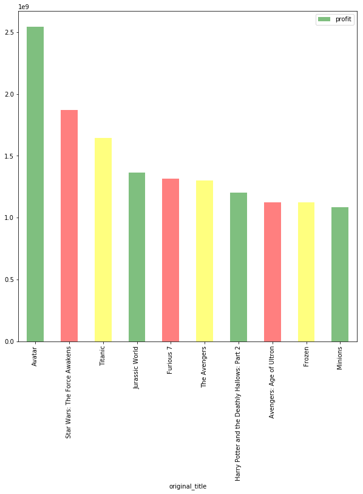

```python
sor_prof_high.plot(x='original_title', y='profit', kind ='bar',alpha =0.5, color =['green', 'red', 'yellow'], figsize=(10,10))
```

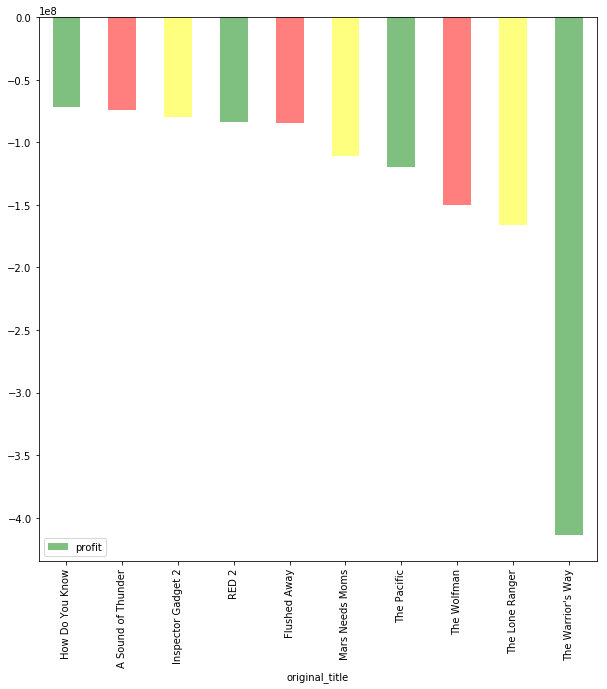

```python
sor_prof_low.plot(x='original_title', y='profit', kind ='bar',alpha= 0.5, color =['green', 'red', 'yellow'], figsize=(10,10))
```

```python
df_02.iloc[1990:, 0:]
```

|  | id | popularity | budget | revenue | original_title | cast | director | runtime | genres | production_companies | release_date | vote_count | release_year | budget_adj | revenue_adj | profit | profit_adj |
| --- | --- | --- | --- | --- | --- | --- | --- | --- | --- | --- | --- | --- | --- | --- | --- | --- | --- |
| 1990 | 13963 | 0.064029 | 0 | 321952 | The Last Waltz | Robbie Robertson\|Rick Danko\|Levon Helm\|Richard... | Martin Scorsese | 117 | Documentary\|Music | FM Productions\|Last Waltz Inc. | 1978-05-01 | 33 | 1978-01-01 | 0 | 1076189 | 321952 | 1076189 |
| 1991 | 16214 | 0.044675 | 0 | 78000000 | Hooper | Burt Reynolds\|Robert Klein\|Adam West\|Jan-Micha... | Hal Needham | 107 | Action\|Comedy | Warner Bros. | 1978-07-28 | 13 | 1978-01-01 | 0 | 260730654 | 78000000 | 260730654 |

```python
sor_prof_low['original_title']
```

```
620        How Do You Know
1529    A Sound of Thunder
1338    Inspector Gadget 2
1385                 RED 2
1583          Flushed Away
993        Mars Needs Moms
669            The Pacific
619            The Wolfman
1400       The Lone Ranger
679      The Warrior's Way
Name: original_title, dtype: object
```

The movie with the highest profit is Avatar with a profit of 2544505847, while the movie with the lowest profit was The Warrior's Way with a profit of -413912431

[figure not shown]

```python
#sor_prof_high.plot(x= 'original_title', y= 'profit', kind ='pie', figsize =(10,10))
values = sor_prof_high['profit']
colors = ['b', 'g', 'r', 'c', 'm', 'y']
labels = sor_prof_high['original_title']
explode = (0.5, 0.3, 0.1, 0.2, 0, 0, 0, 0, 0, 0)
plt.pie(values, colors=colors, labels= labels, explode=explode, counterclock=False, shadow=True)
plt.title('The movies with the highest profit')
plt.legend(values)
plt.show()
```

### Research Question 2 (What are top 10 movies which earn the highest profit?)

```python
# Continue to explore the data to address your additional research
#   questions. Add more headers as needed if you have more questions to
#   investigate.
```

```python
prof_high =df_02.sort_values(['profit'], ascending=False).head(10)
prof_high
```

|  | id | popularity | budget | revenue | original_title | cast | director | runtime | genres | production_companies | release_date | vote_count | release_year | budget_adj | revenue_adj | profit | profit_adj |
| --- | --- | --- | --- | --- | --- | --- | --- | --- | --- | --- | --- | --- | --- | --- | --- | --- | --- |
| 321 | 19995 | 9.432768 | 237000000 | 2781505847 | Avatar | Sam Worthington\|Zoe Saldana\|Sigourney Weaver\|S... | James Cameron | 162 | Action\|Adventure\|Fantasy\|Science Fiction | Ingenious Film Partners\|Twentieth Century Fox ... | 2009-12-10 | 8458 | 2009-01-01 | 240886902 | 2827123750 | 2544505847 | 2586236847 |
| 3 | 140607 | 11.173104 | 200000000 | 2068178225 | Star Wars: The Force Awakens | Harrison Ford\|Mark Hamill\|Carrie Fisher\|Adam D... | J.J. Abrams | 136 | Action\|Adventure\|Science Fiction\|Fantasy | Lucasfilm\|Truenorth Productions\|Bad Robot | 2015-12-15 | 5292 | 2015-01-01 | 183999919 | 1902723129 | 1868178225 | 1718723210 |
| 1347 | 597 | 4.355219 | 200000000 | 1845034188 | Titanic | Kate Winslet\|Leonardo DiCaprio\|Frances Fisher\|... | James Cameron | 194 | Drama\|Romance\|Thriller | Paramount Pictures\|Twentieth Century Fox Film ... | 1997-11-18 | 4654 | 1997-01-01 | 271692064 | 2506405735 | 1645034188 | 2234713671 |
| 0 | 135397 | 32.985763 | 150000000 | 1513528810 | Jurassic World | Chris Pratt\|Bryce Dallas Howard\|Irrfan Khan\|Vi... | Colin Trevorrow | 124 | Action\|Adventure\|Science Fiction\|Thriller | Universal Studios\|Amblin Entertainment\|Legenda... | 2015-06-09 | 5562 | 2015-01-01 | 137999939 | 1392445892 | 1363528810 | 1254445953 |
| 4 | 168259 | 9.335014 | 190000000 | 1506249360 | Furious 7 | Vin Diesel\|Paul Walker\|Jason Statham\|Michelle ... | James Wan | 137 | Action\|Crime\|Thriller | Universal Pictures\|Original Film\|Media Rights ... | 2015-04-01 | 2947 | 2015-01-01 | 174799923 | 1385748801 | 1316249360 | 1210948878 |
| 1162 | 24428 | 7.637767 | 220000000 | 1519557910 | The Avengers | Robert Downey Jr.\|Chris Evans\|Mark Ruffalo\|Chr... | Joss Whedon | 143 | Science Fiction\|Action\|Adventure | Marvel Studios | 2012-04-25 | 8903 | 2012-01-01 | 208943741 | 1443191435 | 1299557910 | 1234247693 |
| 905 | 12445 | 5.711315 | 125000000 | 1327817822 | Harry Potter and the Deathly Hallows: Part 2 | Daniel Radcliffe\|Rupert Grint\|Emma Watson\|Alan... | David Yates | 130 | Adventure\|Family\|Fantasy | Warner Bros.\|Heyday Films\|Moving Picture Compa... | 2011-07-07 | 3750 | 2011-01-01 | 121174755 | 1287183997 | 1202817822 | 1166009242 |
| 14 | 99861 | 5.944927 | 280000000 | 1405035767 | Avengers: Age of Ultron | Robert Downey Jr.\|Chris Hemsworth\|Mark Ruffalo... | Joss Whedon | 141 | Action\|Adventure\|Science Fiction | Marvel Studios\|Prime Focus\|Revolution Sun Studios | 2015-04-22 | 4304 | 2015-01-01 | 257599886 | 1292632336 | 1125035767 | 1035032450 |
| 1358 | 109445 | 6.112766 | 150000000 | 1274219009 | Frozen | Kristen Bell\|Idina Menzel\|Jonathan Groff\|Josh ... | Chris Buck\|Jennifer Lee | 102 | Animation\|Adventure\|Family | Walt Disney Pictures\|Walt Disney Animation Stu... | 2013-11-27 | 3369 | 2013-01-01 | 140405002 | 1192711491 | 1124219009 | 1052306488 |
| 8 | 211672 | 7.404165 | 74000000 | 1156730962 | Minions | Sandra Bullock\|Jon Hamm\|Michael Keaton\|Allison... | Kyle Balda\|Pierre Coffin | 91 | Family\|Animation\|Adventure\|Comedy | Universal Pictures\|Illumination Entertainment | 2015-06-17 | 2893 | 2015-01-01 | 68079970 | 1064192016 | 1082730962 | 996112046 |

```python
df_new = prof_high[['original_title', 'profit', 'budget', 'revenue', 'release_date', 'popularity','runtime']]
df_new
```

|  | original_title | profit | budget | revenue | release_date | popularity | runtime |
| --- | --- | --- | --- | --- | --- | --- | --- |
| 321 | Avatar | 2544505847 | 237000000 | 2781505847 | 2009-12-10 | 9.432768 | 162 |
| 3 | Star Wars: The Force Awakens | 1868178225 | 200000000 | 2068178225 | 2015-12-15 | 11.173104 | 136 |
| 1347 | Titanic | 1645034188 | 200000000 | 1845034188 | 1997-11-18 | 4.355219 | 194 |
| 0 | Jurassic World | 1363528810 | 150000000 | 1513528810 | 2015-06-09 | 32.985763 | 124 |
| 4 | Furious 7 | 1316249360 | 190000000 | 1506249360 | 2015-04-01 | 9.335014 | 137 |
| 1162 | The Avengers | 1299557910 | 220000000 | 1519557910 | 2012-04-25 | 7.637767 | 143 |
| 905 | Harry Potter and the Deathly Hallows: Part 2 | 1202817822 | 125000000 | 1327817822 | 2011-07-07 | 5.711315 | 130 |
| 14 | Avengers: Age of Ultron | 1125035767 | 280000000 | 1405035767 | 2015-04-22 | 5.944927 | 141 |
| 1358 | Frozen | 1124219009 | 150000000 | 1274219009 | 2013-11-27 | 6.112766 | 102 |
| 8 | Minions | 1082730962 | 74000000 | 1156730962 | 2015-06-17 | 7.404165 | 91 |

```python
list(df_new['original_title'])
```

```
['Avatar',
 'Star Wars: The Force Awakens',
 'Titanic',
 'Jurassic World',
 'Furious 7',
 'The Avengers',
 'Harry Potter and the Deathly Hallows: Part 2',
 'Avengers: Age of Ultron',
 'Frozen',
 'Minions']
```

The movies with the top 10 profits are 'Avatar, Star Wars: The Force Awakens, Titanic, Jurassic World, Furious 7, The Avengers, Harry Potter and the Deathly Hallows: Part 2, Avengers: Age of Ultron, Frozen, Minions.

```
array([[<matplotlib.axes._subplots.AxesSubplot object at 0x7f74ee425470>,
      dtype=object)
```

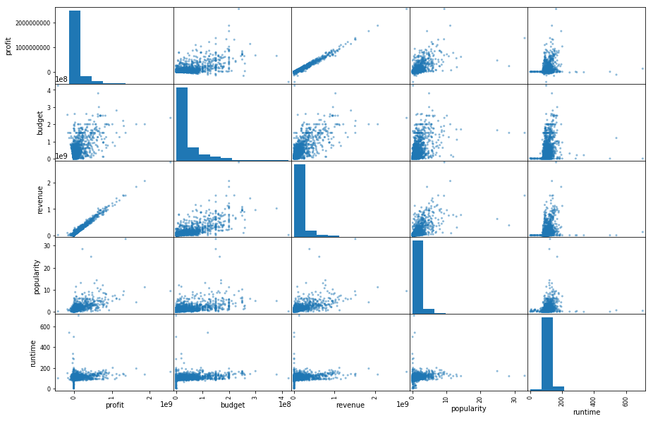

```python
pd.plotting.scatter_matrix(df_02[['profit', 'budget', 'revenue','popularity','runtime']], figsize=(15,10))
```

There looks to be a strong positive correlation between revenue and profit with the profit rising in tandem with revenue. among the others the only other relationship noticed though loosely is the relationship between budget and revenue and popularity has a slight relationship between popularity and revenue.